# RSA

AC / SB

2025-11-07

```r
# RUN ALL CELLS IN THE FILE two_lines_function.Rmd BEFORE RUNNING THE BELOW CODE
```

Set up plotting variables

Wrangle data

# Memory Performance

## Specific source memory increased for high reward memoranda after 24 hrs across all ages

0. Linear age model is best-fitting
1. Main effects of reward level (p < 0.001) and retrieval condition (p < 0.001)

```
Data: assochitd2.long
Models:
assocmemmodelagelin: mem ~ RewardType * RetCond * ageScaled + HighRewardStim + (1 | subid)
assocmemmodelagesq: mem ~ RewardType * RetCond * ageScaled + RewardType * RetCond * ageScaledsq + HighRewardStim + (1 | subid)
                    npar     AIC     BIC logLik deviance  Chisq Df Pr(>Chisq)
assocmemmodelagelin   11 -570.13 -527.51 296.07  -592.13
assocmemmodelagesq    15 -564.11 -505.99 297.06  -594.11 1.9795  4     0.7395
Analysis of Deviance Table (Type III Wald chisquare tests)

Response: mem
                                Chisq Df Pr(>Chisq)
(Intercept)                  825.5358  1  < 2.2e-16 ***
RewardType                    17.8924  1  2.338e-05 ***
RetCond                       49.5615  1  1.922e-12 ***
ageScaled                      1.9936  1     0.1580
HighRewardStim                 0.6316  1     0.4268
RewardType:RetCond             1.8486  1     0.1739
RewardType:ageScaled           0.0000  1     0.9995
RetCond:ageScaled              0.1990  1     0.6555
RewardType:RetCond:ageScaled   0.7667  1     0.3812
---
Signif. codes:  0 ‘***’ 0.001 ‘**’ 0.01 ‘*’ 0.05 ‘.’ 0.1 ‘ ’ 1
```

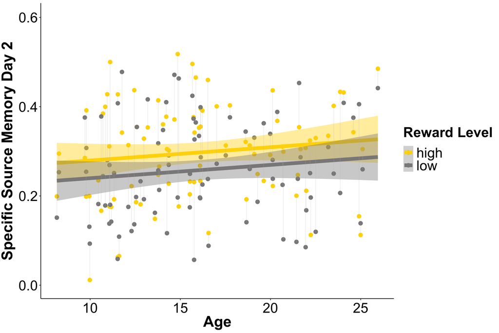

# VTC Pattern Similarity

Wrangle Data

## ERS

0. Quadratic age model is best-fitting
1. Main effect of age (p < 0.01), regardless of controlling for voxel number or removing 1 run subs

```
Data: VTCers.long
Models:
VTCersd1modelagelin: similarity ~ RewardType * ageScaled + HighRewardStim + (1 | subid)
VTCersd1modelagesq: similarity ~ RewardType * ageScaled + RewardType * ageScaledsq + HighRewardStim + (1 | subid)
                    npar     AIC     BIC logLik deviance  Chisq Df Pr(>Chisq)
VTCersd1modelagelin    7 -635.77 -613.50 324.88  -649.77
VTCersd1modelagesq     9 -639.19 -610.56 328.60  -657.19 7.4258  2    0.02441 *
---
Signif. codes:  0 ‘***’ 0.001 ‘**’ 0.01 ‘*’ 0.05 ‘.’ 0.1 ‘ ’ 1
Analysis of Deviance Table (Type III Wald chisquare tests)

Response: similarity
                          Chisq Df Pr(>Chisq)
(Intercept)            160.5749  1  < 2.2e-16 ***
RewardType               1.5529  1   0.212712
ageScaled                0.9232  1   0.336647
ageScaledsq              7.0190  1   0.008065 **
HighRewardStim           0.3076  1   0.579187
RewardType:ageScaled     0.0256  1   0.872976
RewardType:ageScaledsq   0.3526  1   0.552618
---
Signif. codes:  0 ‘***’ 0.001 ‘**’ 0.01 ‘*’ 0.05 ‘.’ 0.1 ‘ ’ 1
Analysis of Deviance Table (Type III Wald chisquare tests)

Response: similarity
                          Chisq Df Pr(>Chisq)
(Intercept)            160.1296  1  < 2.2e-16 ***
RewardType               1.5529  1   0.212712
ageScaled                0.8688  1   0.351278
ageScaledsq              6.9375  1   0.008441 **
HighRewardStim           0.3129  1   0.575930
goldencvoxnumScaled      0.6727  1   0.412125
RewardType:ageScaled     0.0256  1   0.872976
RewardType:ageScaledsq   0.3526  1   0.552618
---
Signif. codes:  0 ‘***’ 0.001 ‘**’ 0.01 ‘*’ 0.05 ‘.’ 0.1 ‘ ’ 1
Analysis of Deviance Table (Type III Wald chisquare tests)

Response: similarity
                          Chisq Df Pr(>Chisq)
```

[output cut: 37 more lines]

```
Correlation of Fixed Effects:
            (Intr) RwrdTy agScld HRRC-P
RewardTyplw -0.133
ageScaled   -0.015  0.000
HghRwSHRC-P -0.705  0.000  0.021
RwrdTyplw:S  0.000  0.000 -0.188  0.000
Data: VTCers.long
Models:
VTCersd1modelagelin: similarity ~ RewardType * ageScaled + HighRewardStim + (1 | subid)
VTCersd1modelagesq: similarity ~ RewardType * ageScaled + RewardType * ageScaledsq + HighRewardStim + (1 | subid)
                    npar     AIC     BIC logLik deviance  Chisq Df Pr(>Chisq)
VTCersd1modelagelin    7 -635.77 -613.50 324.88  -649.77
VTCersd1modelagesq     9 -639.19 -610.56 328.60  -657.19 7.4258  2    0.02441 *
---
Signif. codes:  0 ‘***’ 0.001 ‘**’ 0.01 ‘*’ 0.05 ‘.’ 0.1 ‘ ’ 1
```

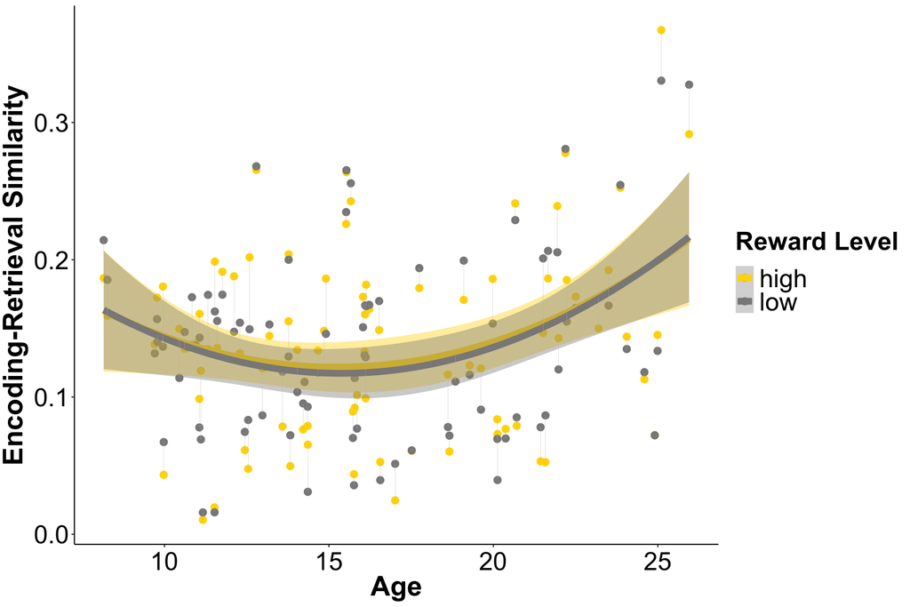

## Encoding Similarity

0. Linear age model is best-fitting
1. Main effects of reward level (p < 0.001) and age (p < 0.05), regardless of controlling for voxel number or removing 1 run subs

```
Data: VTCencsim.long
Models:
VTCencsimd1modelagelin: similarity ~ RewardType * ageScaled + HighRewardStim + (1 | subid)
VTCencsimd1modelagesq: similarity ~ RewardType * ageScaled + RewardType * ageScaledsq + HighRewardStim + (1 | subid)
                       npar     AIC     BIC logLik deviance  Chisq Df Pr(>Chisq)
VTCencsimd1modelagelin    7 -434.15 -413.27 224.08  -448.15
VTCencsimd1modelagesq     9 -431.66 -404.81 224.83  -449.66 1.5103  2     0.4699
Analysis of Deviance Table (Type III Wald chisquare tests)

Response: similarity
                        Chisq Df Pr(>Chisq)
(Intercept)          257.9367  1  < 2.2e-16 ***
RewardType            13.8480  1  0.0001982 ***
ageScaled              4.3820  1  0.0363212 *
HighRewardStim         1.3402  1  0.2469974
RewardType:ageScaled   0.1209  1  0.7280601
---
Signif. codes:  0 ‘***’ 0.001 ‘**’ 0.01 ‘*’ 0.05 ‘.’ 0.1 ‘ ’ 1
Analysis of Deviance Table (Type III Wald chisquare tests)

Response: similarity
                        Chisq Df Pr(>Chisq)
(Intercept)          257.4219  1  < 2.2e-16 ***
RewardType            13.8480  1  0.0001982 ***
ageScaled              3.8598  1  0.0494559 *
HighRewardStim         1.3290  1  0.2489831
goldencvoxnumScaled    0.7466  1  0.3875695
RewardType:ageScaled   0.1209  1  0.7280601
---
Signif. codes:  0 ‘***’ 0.001 ‘**’ 0.01 ‘*’ 0.05 ‘.’ 0.1 ‘ ’ 1
Analysis of Deviance Table (Type III Wald chisquare tests)

Response: similarity
                        Chisq Df Pr(>Chisq)
(Intercept)          257.9367  1  < 2.2e-16 ***
RewardType            13.8480  1  0.0001982 ***
ageScaled              4.3820  1  0.0363212 *
HighRewardStim         1.3402  1  0.2469974
RewardType:ageScaled   0.1209  1  0.7280601
---
Signif. codes:  0 ‘***’ 0.001 ‘**’ 0.01 ‘*’ 0.05 ‘.’ 0.1 ‘ ’ 1
```

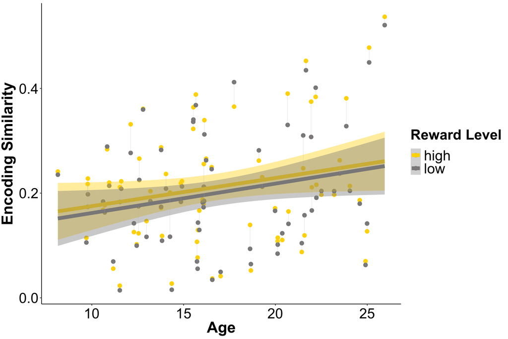

## Retrieval Similarity

0. Linear age model is best-fitting
1. No effects

```
Data: VTCretsim.long
Models:
VTCretsimd1modelagelin: similarity ~ RewardType * ageScaled + HighRewardStim + (1 | subid)
VTCretsimd1modelagesq: similarity ~ RewardType * ageScaled + RewardType * ageScaledsq + HighRewardStim + (1 | subid)
                       npar     AIC     BIC logLik deviance  Chisq Df Pr(>Chisq)
VTCretsimd1modelagelin    7 -530.23 -509.34 272.11  -544.23
VTCretsimd1modelagesq     9 -530.35 -503.50 274.17  -548.35 4.1215  2     0.1274
Analysis of Deviance Table (Type III Wald chisquare tests)

Response: similarity
                        Chisq Df Pr(>Chisq)
(Intercept)          378.3351  1     <2e-16 ***
RewardType             0.9268  1     0.3357
ageScaled              1.4320  1     0.2314
HighRewardStim         1.4449  1     0.2293
RewardType:ageScaled   0.0286  1     0.8656
---
Signif. codes:  0 ‘***’ 0.001 ‘**’ 0.01 ‘*’ 0.05 ‘.’ 0.1 ‘ ’ 1
```

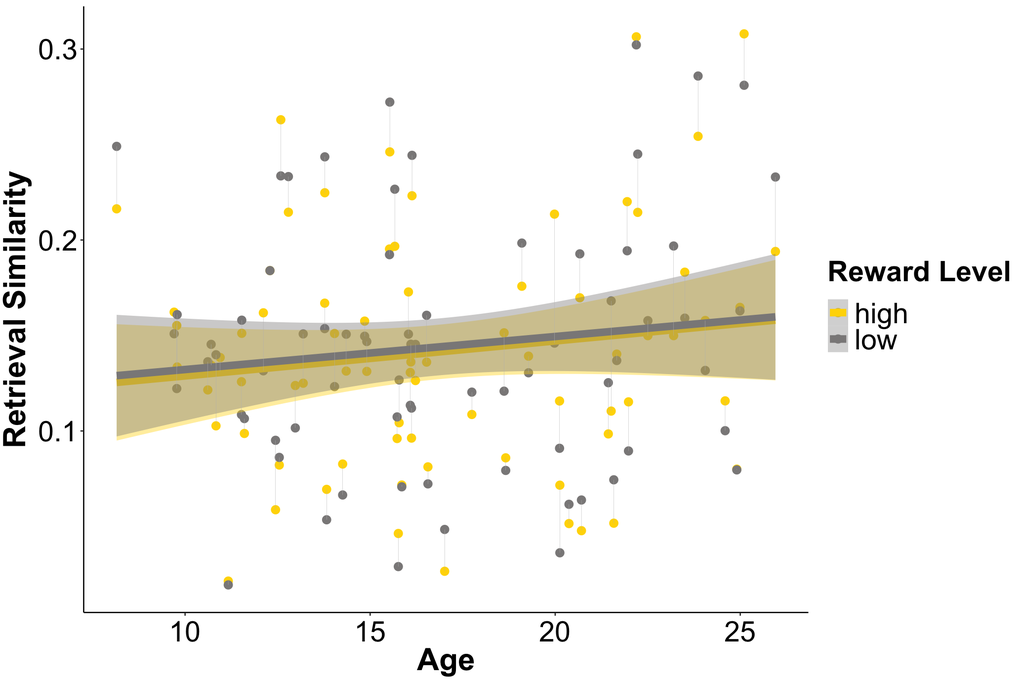

# Anterior Hippocampus Pattern Similarity

## ERS

0. Linear age model is best-fitting
1. Interaction between reward level and age (p < 0.01), regardless of controlling for voxel number or removing 1 run subs

```
Data: anthippers.long
Models:
anthippersd1modelagelin: similarity ~ RewardType * ageScaled + HighRewardStim + (1 | subid)
anthippersd1modelagesq: similarity ~ RewardType * ageScaled + RewardType * ageScaledsq + HighRewardStim + (1 | subid)
                        npar     AIC     BIC logLik deviance  Chisq Df Pr(>Chisq)
anthippersd1modelagelin    7 -764.18 -741.91 389.09  -778.18
anthippersd1modelagesq     9 -763.92 -735.28 390.96  -781.92 3.7401  2     0.1541
Analysis of Deviance Table (Type III Wald chisquare tests)

Response: similarity
                      Chisq Df Pr(>Chisq)
(Intercept)          2.4476  1   0.117707
RewardType           1.5299  1   0.216122
ageScaled            1.5259  1   0.216727
HighRewardStim       0.0029  1   0.956885
RewardType:ageScaled 9.4089  1   0.002159 **
---
Signif. codes:  0 ‘***’ 0.001 ‘**’ 0.01 ‘*’ 0.05 ‘.’ 0.1 ‘ ’ 1
Analysis of Deviance Table (Type III Wald chisquare tests)

Response: similarity
                      Chisq Df Pr(>Chisq)
(Intercept)          2.4261  1   0.119327
RewardType           1.5299  1   0.216122
ageScaled            1.5405  1   0.214549
HighRewardStim       0.0033  1   0.954171
goldencvoxnumScaled  0.2511  1   0.616322
RewardType:ageScaled 9.4089  1   0.002159 **
---
Signif. codes:  0 ‘***’ 0.001 ‘**’ 0.01 ‘*’ 0.05 ‘.’ 0.1 ‘ ’ 1
Analysis of Deviance Table (Type III Wald chisquare tests)

Response: similarity
                      Chisq Df Pr(>Chisq)
(Intercept)          1.0369  1     0.3086
RewardType           1.1451  1     0.2846
ageScaled            0.1238  1     0.7250
HighRewardStim       0.0297  1     0.8632
RewardType:ageScaled 4.9365  1     0.0263 *
---
Signif. codes:  0 ‘***’ 0.001 ‘**’ 0.01 ‘*’ 0.05 ‘.’ 0.1 ‘ ’ 1
```

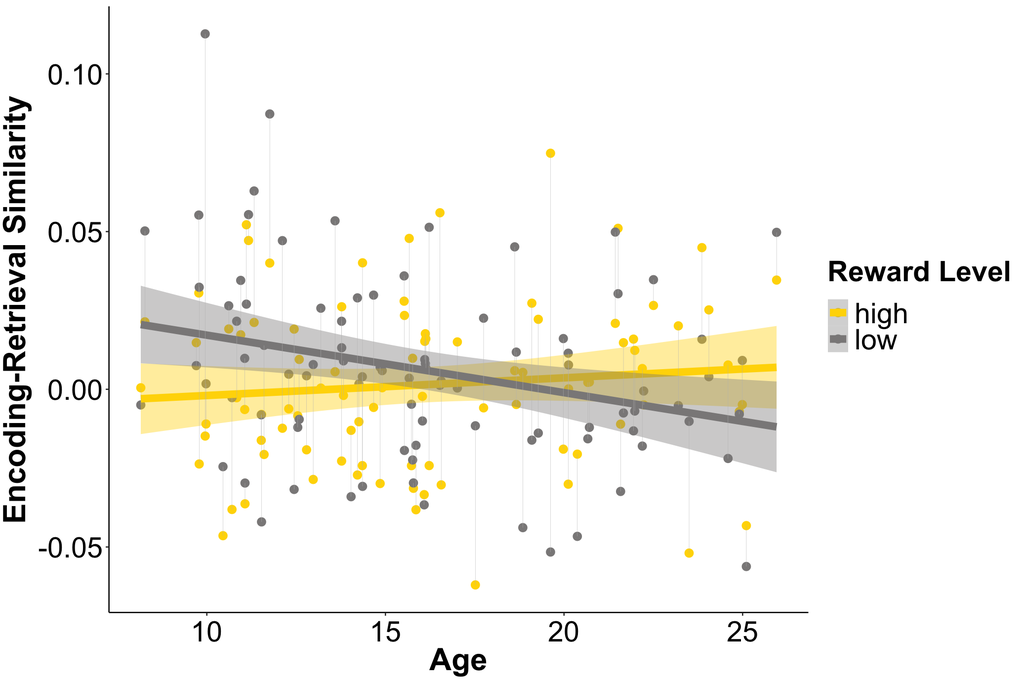

## Encoding Similarity

0. Linear age model is best-fitting
1. No effects, regardless of controlling for voxel number

```
Data: anthippencsim.long
Models:
anthippencsimd1modelagelin: similarity ~ RewardType * ageScaled + HighRewardStim + (1 | subid)
anthippencsimd1modelagesq: similarity ~ RewardType * ageScaled + RewardType * ageScaledsq + HighRewardStim + (1 | subid)
                           npar     AIC     BIC logLik deviance  Chisq Df Pr(>Chisq)
anthippencsimd1modelagelin    7 -731.95 -711.07 372.98  -745.95
anthippencsimd1modelagesq     9 -729.11 -702.26 373.55  -747.11 1.1562  2      0.561
Analysis of Deviance Table (Type III Wald chisquare tests)

Response: similarity
                       Chisq Df Pr(>Chisq)
(Intercept)          26.1044  1  3.234e-07 ***
RewardType            0.3252  1     0.5685
ageScaled             0.2013  1     0.6537
HighRewardStim        0.9699  1     0.3247
RewardType:ageScaled  1.0964  1     0.2951
---
Signif. codes:  0 ‘***’ 0.001 ‘**’ 0.01 ‘*’ 0.05 ‘.’ 0.1 ‘ ’ 1
Analysis of Deviance Table (Type III Wald chisquare tests)

Response: similarity
                       Chisq Df Pr(>Chisq)
(Intercept)          27.5386  1   1.54e-07 ***
RewardType            0.3252  1     0.5685
ageScaled             0.4009  1     0.5266
HighRewardStim        0.9004  1     0.3427
goldencvoxnumScaled   1.6902  1     0.1936
RewardType:ageScaled  1.0964  1     0.2951
---
Signif. codes:  0 ‘***’ 0.001 ‘**’ 0.01 ‘*’ 0.05 ‘.’ 0.1 ‘ ’ 1
```

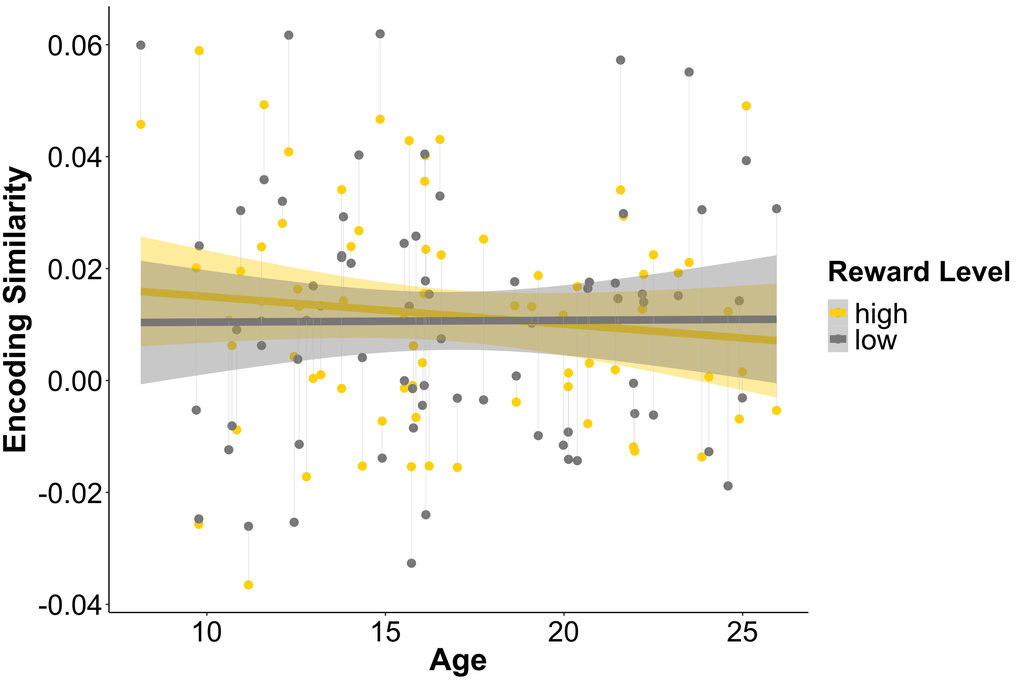

## Retrieval Similarity

0. Linear age model is best-fitting
1. No effects, regardless of controlling for voxel number

```
Data: anthippretsim.long
Models:
anthippretsimd1modelagelin: similarity ~ RewardType * ageScaled + HighRewardStim + (1 | subid)
anthippretsimd1modelagesq: similarity ~ RewardType * ageScaled + RewardType * ageScaledsq + HighRewardStim + (1 | subid)
                           npar     AIC     BIC logLik deviance  Chisq Df Pr(>Chisq)
anthippretsimd1modelagelin    7 -690.46 -669.57 352.23  -704.46
anthippretsimd1modelagesq     9 -689.77 -662.92 353.89  -707.77 3.3117  2     0.1909
Analysis of Deviance Table (Type III Wald chisquare tests)

Response: similarity
                       Chisq Df Pr(>Chisq)
(Intercept)          28.2522  1  1.065e-07 ***
RewardType            0.8867  1     0.3464
ageScaled             0.1883  1     0.6643
HighRewardStim        0.0311  1     0.8600
RewardType:ageScaled  0.5084  1     0.4758
---
Signif. codes:  0 ‘***’ 0.001 ‘**’ 0.01 ‘*’ 0.05 ‘.’ 0.1 ‘ ’ 1
Analysis of Deviance Table (Type III Wald chisquare tests)

Response: similarity
                       Chisq Df Pr(>Chisq)
(Intercept)          28.9388  1   7.47e-08 ***
RewardType            0.8867  1     0.3464
ageScaled             0.0878  1     0.7669
HighRewardStim        0.0217  1     0.8828
goldretvoxnumScaled   0.8502  1     0.3565
RewardType:ageScaled  0.5084  1     0.4758
---
Signif. codes:  0 ‘***’ 0.001 ‘**’ 0.01 ‘*’ 0.05 ‘.’ 0.1 ‘ ’ 1
```

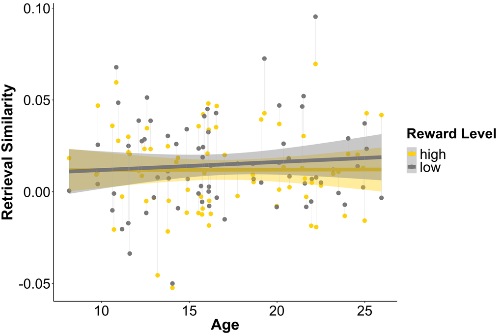

# Brain-Behavior & Brain-Brain Relations

# Trialwise VTC ERS

0. Greater VTC ERS is associated with better specific source memory on day 2

Model

Plot

```r
# Fit model for plotting
VTCERStrialwiseplotting <- glmer(memory ~ ERS + RewardType + ageScaled + HighRewardStim + (RewardType|subid), family = binomial, control = glmerControl(optimizer = "bobyqa", optCtrl = list(maxfun=1e6)), contrasts = list(RewardType = "contr.sum", HighRewardStim = "contr.sum"), data = trialwiseVTCERSwdemog)
Anova(VTCERStrialwiseplotting, type = "III")
```

```
Analysis of Deviance Table (Type III Wald chisquare tests)

Response: memory
                 Chisq Df Pr(>Chisq)
(Intercept)     3.0669  1   0.079904 .
ERS            17.0428  1  3.655e-05 ***
RewardType      7.2570  1   0.007062 **
ageScaled       4.2181  1   0.039994 *
HighRewardStim  0.0072  1   0.932516
---
Signif. codes:  0 ‘***’ 0.001 ‘**’ 0.01 ‘*’ 0.05 ‘.’ 0.1 ‘ ’ 1
```

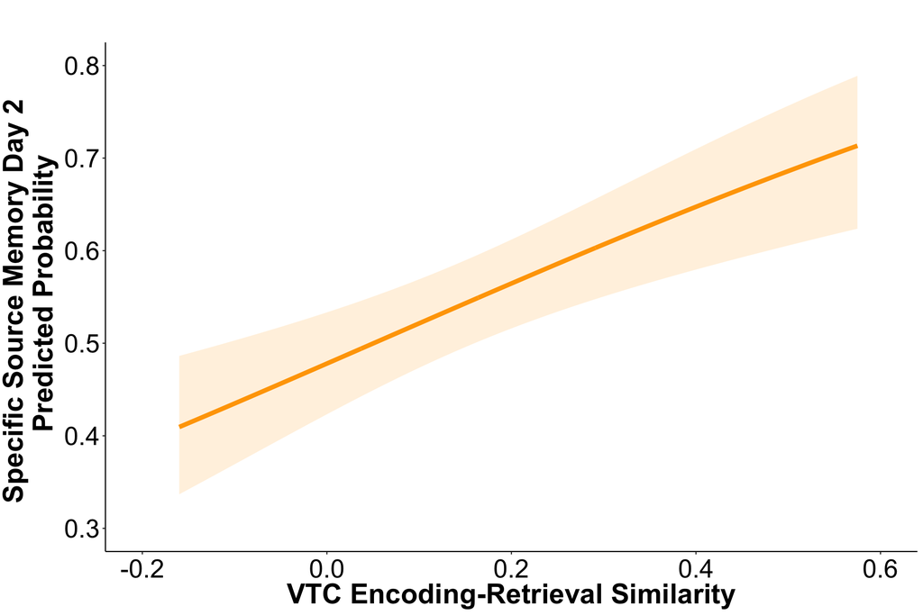

```r
# Plot
vtcplot <- plot_model(VTCERStrialwiseplotting, type = "pred", terms = c("ERS [all]"),
           title="", line.size=2, colors="orange") +
  xlab("VTC Encoding-Retrieval Similarity") +
  ylab("Specific Source Memory Day 2 \n Predicted Probability") +
  xlim(-0.2, 0.6) +
  scale_y_continuous(limits = c(0.3, 0.8)) +  # set probability range
  theme(
    title = element_text(size=26, vjust=2, face="bold"),
    axis.title.x = element_text(size=26),
    axis.title.y = element_text(size=26, vjust=1.5),
    axis.text.x = element_text(size=24, colour="black", vjust=0.6),
    axis.text.y = element_text(size=24, colour="black"),
    strip.text = element_text(size=24, face="bold"),
    panel.grid.major = element_blank(),
    panel.grid.minor = element_blank(),
    panel.background = element_blank(),
    axis.line = element_line(colour = "black"))
vtcplot
```

## Memory vs. Hippocampal ERS, VTC Encoding Similarity

- AntHipp ERS absolute value = significant
- VTC encoding similarity = marginal

```
Call:
lm(formula = highvlowspecificmemd2 ~ highvlowERSabs + VTC.highvlowencsim +
    ageScaled + HighRewardStim, data = anthippRSAdatawbehavfullruns)

Residuals:
      Min        1Q    Median        3Q       Max
-0.284679 -0.062186  0.004287  0.051144  0.217183

Coefficients:
                                       Estimate Std. Error t value Pr(>|t|)
(Intercept)                           -0.024624   0.024368  -1.010  0.31585
highvlowERSabs                         2.698326   0.788071   3.424  0.00105 **
VTC.highvlowencsim                     0.841374   0.463675   1.815  0.07400 .
ageScaled                              0.001505   0.012110   0.124  0.90144
HighRewardStimHigh Reward Cat - Place -0.003522   0.024083  -0.146  0.88415
---
Signif. codes:  0 ‘***’ 0.001 ‘**’ 0.01 ‘*’ 0.05 ‘.’ 0.1 ‘ ’ 1

Residual standard error: 0.1024 on 68 degrees of freedom
Multiple R-squared:  0.2029,    Adjusted R-squared:  0.156
F-statistic: 4.328 on 4 and 68 DF,  p-value: 0.003536
```

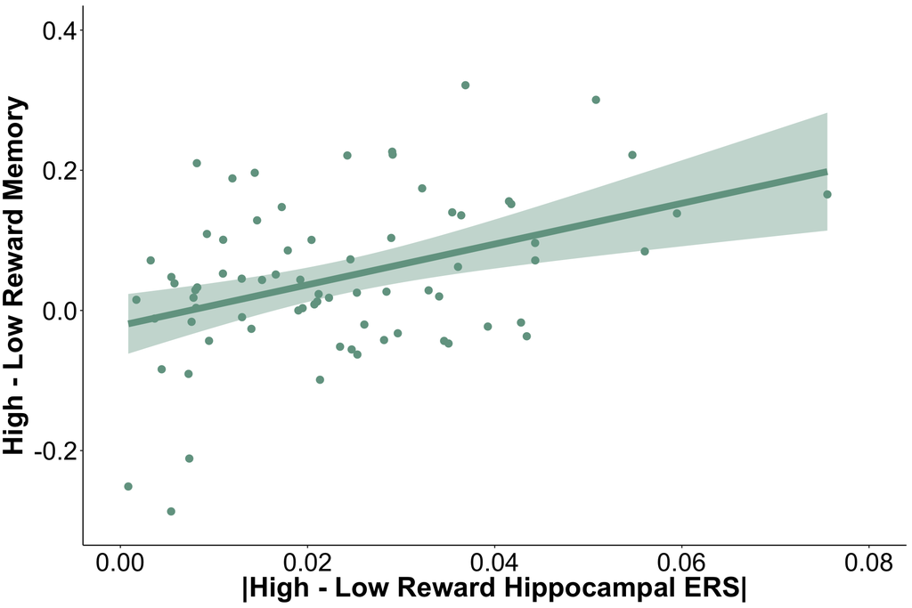

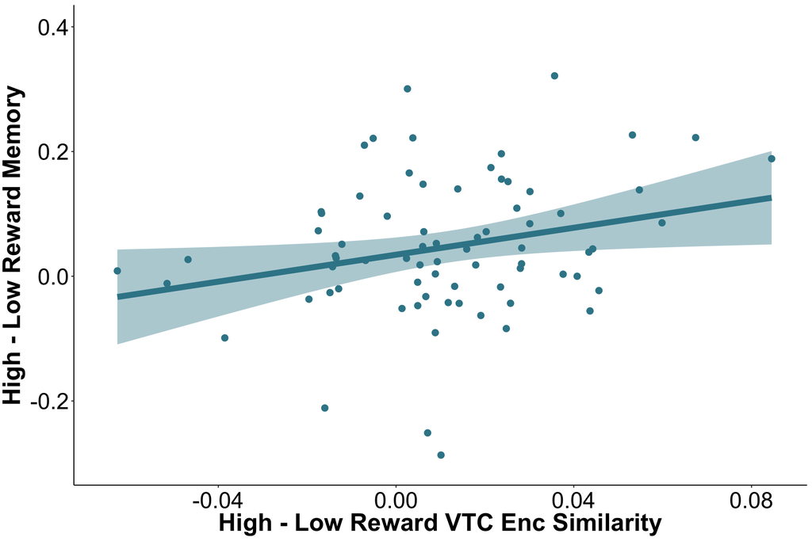

## Hippocampal ERS vs. VTA Encoding Activation

- VTA encoding activation = significant
- age = marginal

```
Call:
lm(formula = highvlowERS ~ VTA * ageScaled + HighRewardStim,
    data = anthippRSAdatawbehavfullruns)

Residuals:
      Min        1Q    Median        3Q       Max
-0.072556 -0.017396 -0.000258  0.019100  0.058890

Coefficients:
                                        Estimate Std. Error t value Pr(>|t|)
(Intercept)                           -0.0007279  0.0049501  -0.147   0.8835
VTA                                   -0.0216526  0.0095308  -2.272   0.0263 *
ageScaled                              0.0073882  0.0040890   1.807   0.0752 .
HighRewardStimHigh Reward Cat - Place  0.0021026  0.0066552   0.316   0.7530
VTA:ageScaled                          0.0068634  0.0112692   0.609   0.5445
---
Signif. codes:  0 ‘***’ 0.001 ‘**’ 0.01 ‘*’ 0.05 ‘.’ 0.1 ‘ ’ 1

Residual standard error: 0.02708 on 68 degrees of freedom
Multiple R-squared:  0.1335,    Adjusted R-squared:  0.08252
F-statistic: 2.619 on 4 and 68 DF,  p-value: 0.04243
```

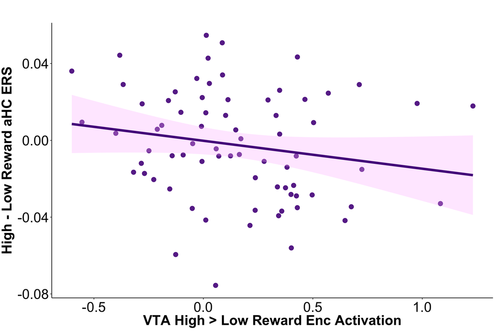

## VTC Encoding Similarity vs. dlPFC Encoding Activation

- dlPFC encoding activation = significant

```
Call:
lm(formula = VTC.highvlowencsim ~ dlPFC * ageScaled + HighRewardStim,
    data = anthippRSAdatawbehavfullruns)

Residuals:
      Min        1Q    Median        3Q       Max
-0.067777 -0.016758 -0.002033  0.012705  0.058763

Coefficients:
                                        Estimate Std. Error t value Pr(>|t|)
(Intercept)                            0.0031037  0.0042450   0.731    0.467
dlPFC                                  0.0116198  0.0026357   4.409 3.79e-05 ***
ageScaled                             -0.0030698  0.0033570  -0.914    0.364
HighRewardStimHigh Reward Cat - Place  0.0016807  0.0056392   0.298    0.767
dlPFC:ageScaled                       -0.0006188  0.0024077  -0.257    0.798
---
Signif. codes:  0 ‘***’ 0.001 ‘**’ 0.01 ‘*’ 0.05 ‘.’ 0.1 ‘ ’ 1

Residual standard error: 0.02388 on 68 degrees of freedom
Multiple R-squared:  0.2265,    Adjusted R-squared:  0.181
F-statistic: 4.977 on 4 and 68 DF,  p-value: 0.001405
```

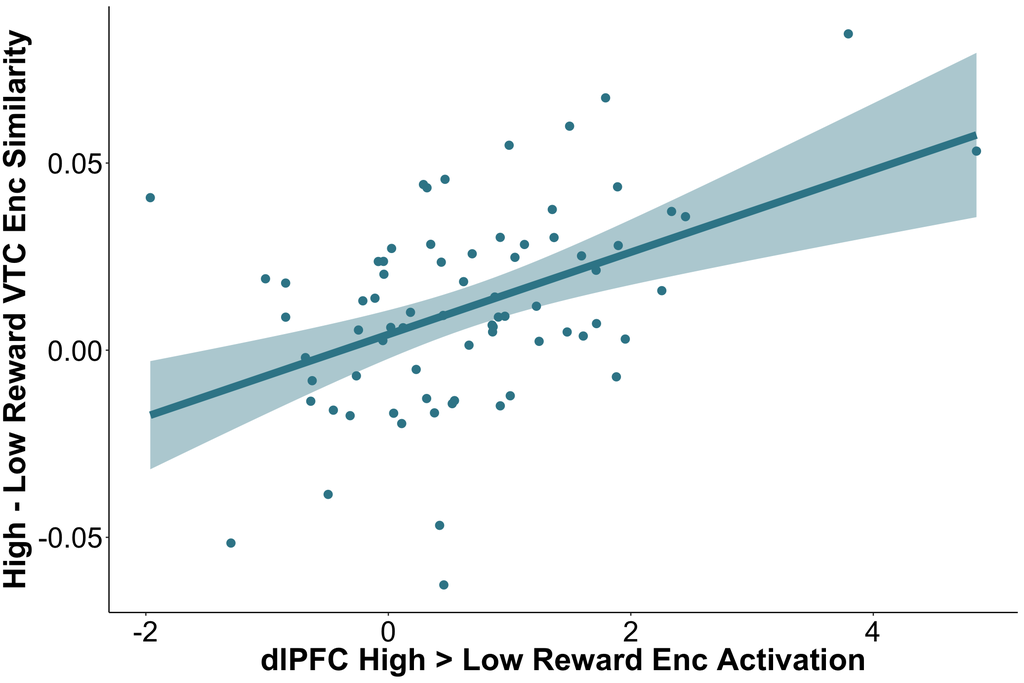

# Encoding Activation Tradeoff

- significant

```
Call:
lm(formula = dlPFC ~ VTA, data = anthippRSAdatawbehavfullruns)

Residuals:
    Min      1Q  Median      3Q     Max
-2.2832 -0.6385 -0.1263  0.5527  3.7305

Coefficients:
            Estimate Std. Error t value Pr(>|t|)
(Intercept)   0.5456     0.1348   4.046 0.000131 ***
VTA           0.8072     0.3467   2.328 0.022754 *
---
Signif. codes:  0 ‘***’ 0.001 ‘**’ 0.01 ‘*’ 0.05 ‘.’ 0.1 ‘ ’ 1

Residual standard error: 1.062 on 71 degrees of freedom
Multiple R-squared:  0.07093,   Adjusted R-squared:  0.05785
F-statistic: 5.421 on 1 and 71 DF,  p-value: 0.02275
```

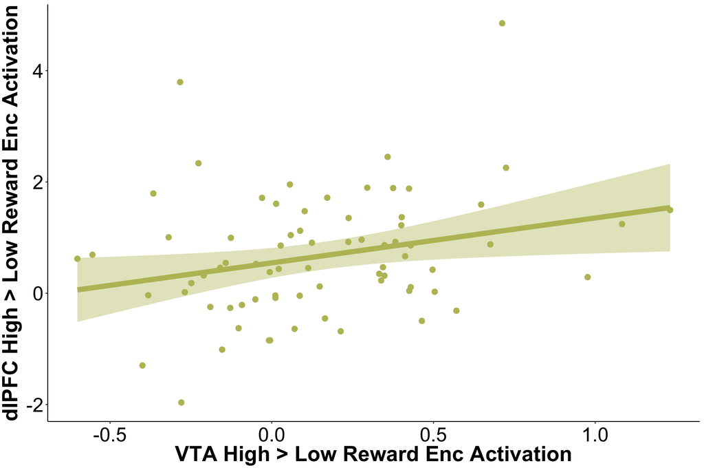

# ERS by non-linear age

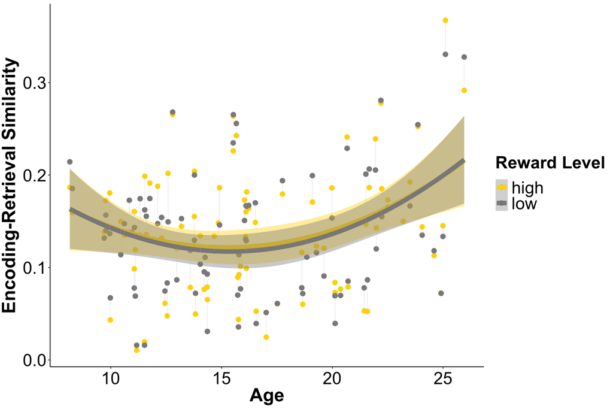

```r
# Plot
agesqvtcers<-ggplot(VTCers.long, aes(y = similarity, x = ExactAge, colour = RewardType, group = RewardType)) +
  geom_point(size = 3) + # make each subject a different color dot
  stat_smooth(method = "glm",formula = y~poly(x, 2), fullrange = TRUE, aes(fill = RewardType), size = 3) + # add line of best fit
  #stat_smooth(method = "lm", se = TRUE) +
  xlab("Age") + # x axis label
  ylab("Encoding-Retrieval Similarity") + # y axis label
  # ggtitle("All trials") +
  scale_colour_manual(values = c("gold", "snow4"), name = "Reward Level") +
  scale_fill_manual(values = c("gold", "snow4"), guide = "none") +
  geom_line(aes(group = subid), color = "grey", size = .1) +
  # ylim(0, 0.602) +
  rsa_theme
#ggsave('figures/VTC_ERS.png', width = 12, height = 8)
agesqvtcers
```

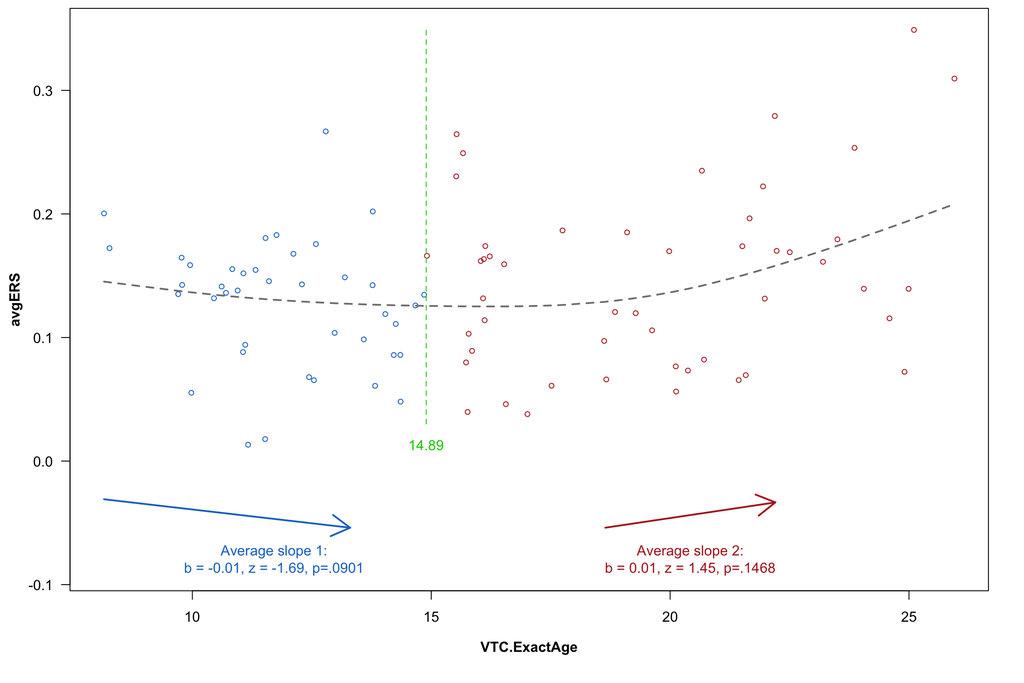

```r
# Compute average for two-lines test
VTCRSAdata$avgERS <- (VTCRSAdata$VTC.highrewardERS + VTCRSAdata$VTC.lowrewardERS) / 2
twolineplot<-twolines(avgERS~VTC.ExactAge, graph = 1, link = "gaussian",data = VTCRSAdata)
```

# aHC ERS by age group instead of continuous age

Age Group Model

```r
anthippers.long$AgeGroup <- factor(anthippers.long$AgeGroup)

summary(anthippersinter<- lmer(similarity ~ RewardType*AgeGroup + HighRewardStim + (1|subid), REML = FALSE, control = lmerControl(optimizer = "bobyqa", optCtrl = list(maxfun=1e6)), data = anthippers.long))
```

```
Linear mixed model fit by maximum likelihood . t-tests use Satterthwaite's method ['lmerModLmerTest']
Formula: similarity ~ RewardType * AgeGroup + HighRewardStim + (1 | subid)
   Data: anthippers.long
Control: lmerControl(optimizer = "bobyqa", optCtrl = list(maxfun = 1e+06))

     AIC      BIC   logLik deviance df.resid
  -761.9   -733.2    389.9   -779.9      169

Scaled residuals:
    Min      1Q  Median      3Q     Max
-2.2187 -0.5948 -0.0380  0.5835  3.3050

Random effects:
 Groups   Name        Variance  Std.Dev.
 subid    (Intercept) 0.0002006 0.01416
 Residual             0.0005587 0.02364
Number of obs: 178, groups:  subid, 89

Fixed effects:
                                        Estimate Std. Error         df t value Pr(>|t|)
(Intercept)                            7.402e-03  5.542e-03  1.541e+02   1.336  0.18363
RewardTypelow                         -1.057e-02  6.103e-03  8.900e+01  -1.732  0.08668 .
AgeGroup2                             -1.019e-02  7.058e-03  1.664e+02  -1.444  0.15054
AgeGroup3                             -7.671e-03  7.243e-03  1.664e+02  -1.059  0.29106
HighRewardStimHigh Reward Cat - Place  8.537e-05  4.649e-03  8.900e+01   0.018  0.98539
RewardTypelow:AgeGroup2                1.736e-02  8.561e-03  8.900e+01   2.028  0.04555 *
RewardTypelow:AgeGroup3                2.856e-02  8.784e-03  8.900e+01   3.251  0.00162 **
---
Signif. codes:  0 ‘***’ 0.001 ‘**’ 0.01 ‘*’ 0.05 ‘.’ 0.1 ‘ ’ 1

Correlation of Fixed Effects:
            (Intr) RwrdTy AgGrp2 AgGrp3 HRRC-P RT:AG2
RewardTyplw -0.551
AgeGroup2   -0.652  0.432
AgeGroup3   -0.621  0.421  0.495
HghRwSHRC-P -0.419  0.000  0.011 -0.023
RwrdTyp:AG2  0.393 -0.713 -0.607 -0.300  0.000
RwrdTyp:AG3  0.383 -0.695 -0.300 -0.606  0.000  0.495
```

Examine marginal means from reward x age group interaction

```r
# get emmeans
emm <- emmeans(anthippersinter, ~ RewardType * AgeGroup)

# compare reward type within each age group
pairs(emm, by = "AgeGroup")
```

```
AgeGroup = 1:
 contrast   estimate      SE   df t.ratio p.value
 high - low  0.01057 0.00621 92.1   1.703  0.0920

AgeGroup = 2:
 contrast   estimate      SE   df t.ratio p.value
 high - low -0.00679 0.00611 92.1  -1.112  0.2692

AgeGroup = 3:
 contrast   estimate      SE   df t.ratio p.value
 high - low -0.01798 0.00643 92.1  -2.798  0.0063

Results are averaged over the levels of: HighRewardStim
Degrees-of-freedom method: kenward-roger
```

Plot ERS by Age Group

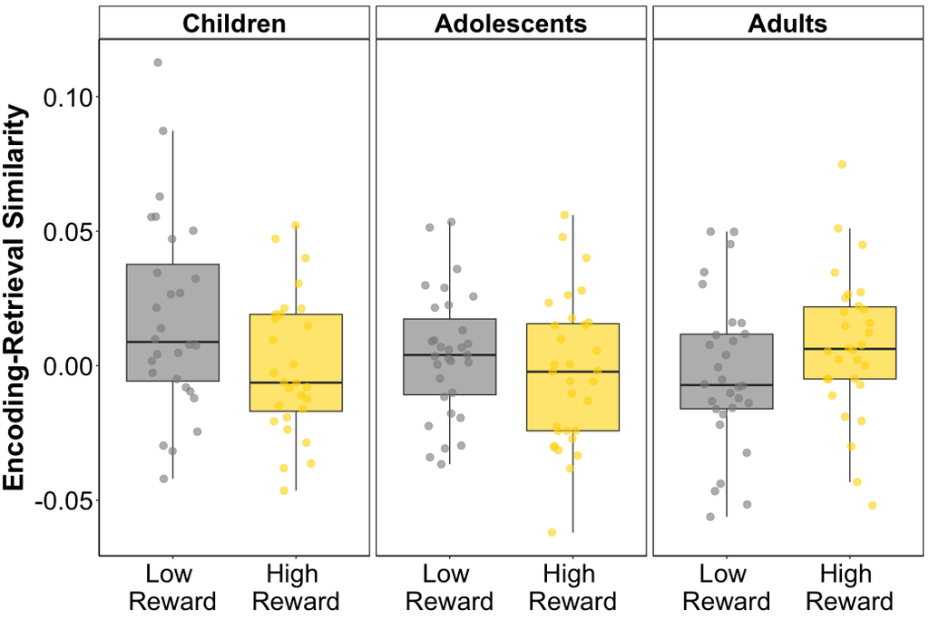

```r
anthippers.long <- anthippers.long %>%
  mutate(AgeGrouplab = factor(AgeGroup, levels = c(3, 2, 1), # order: kids, teens, adults
                           labels = c("Children", "Adolescents", "Adults")),
         RewardTypelab = factor(RewardType, levels = c("low", "high"),
                                                       labels = c("Low \nReward", "High \nReward")))  # relabel

agebinboxplot<- ggplot(anthippers.long, aes(
    x = RewardTypelab, y = similarity, fill = RewardTypelab)) +
  geom_boxplot(outlier.shape = NA, alpha = 0.6) +
  geom_jitter(
    aes(color = RewardTypelab),
    width = 0.2, alpha = 0.6, size = 3, stroke = 0.5, ) +
  ylab("Encoding-Retrieval Similarity") +
  xlab(NULL) +
  scale_fill_manual(values = c("snow4","gold"), guide = "none") + # guide = none removes the legend
  scale_color_manual(values = c("snow4","gold"), guide = "none") +
  facet_wrap(~AgeGrouplab, ncol = 3) +
  rsa_theme + theme(
    strip.background = element_rect(fill = "white", color = "black", linewidth = 0.8),
    strip.text = element_text(color = "black", face = "bold"),
        panel.border = element_rect(color = "black", fill = NA, linewidth = 0.8) # outline each facet panel
  )

agebinboxplot
```

# aHC ERS by correct/incorrect, separately for adults and children

Model

Plot

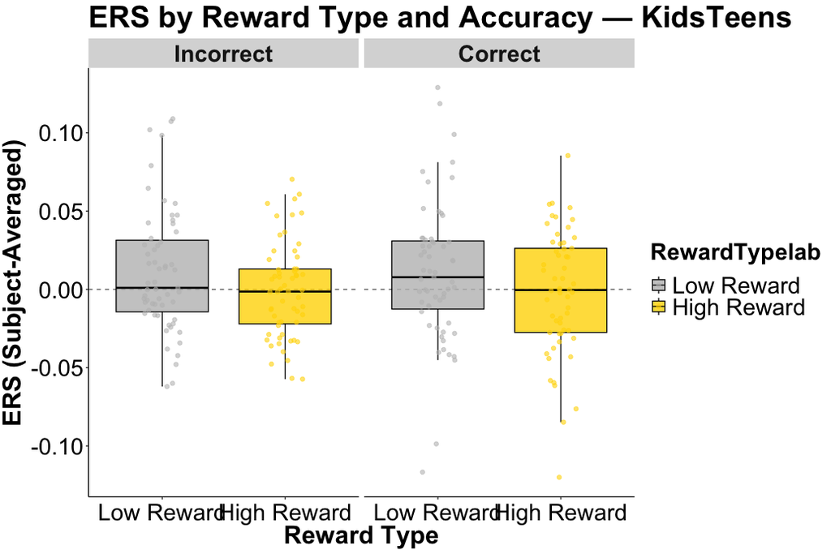

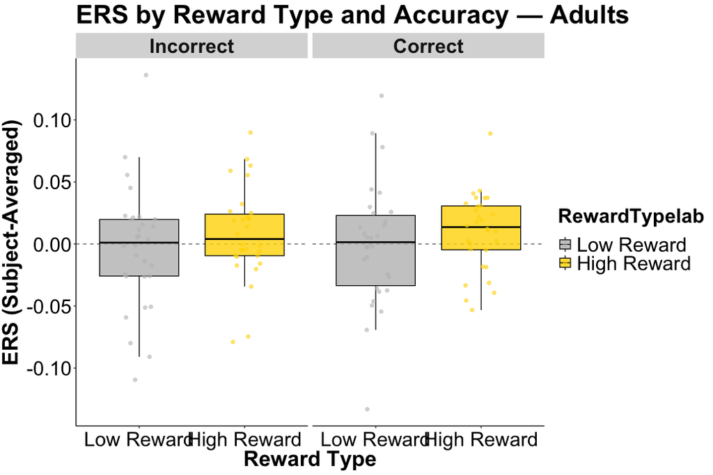

```r
# Define your groups
groups <- list("KidsTeens" = trialwiseaHCERSwdemog %>% filter(AgeGroup != 1),
               "Adults" = trialwiseaHCERSwdemog %>% filter(AgeGroup == 1))

# Loop through both datasets
for (g in names(groups)) {
  trial_data <- groups[[g]]

  # Subject-level averages
  trialwiseaHC_avg <- trial_data %>%
    group_by(subid, RewardType, memory) %>%
    summarise(ERS = mean(ERS, na.rm = TRUE), .groups = "drop") %>%
    mutate(
      Group = interaction(RewardType, memory, sep = " & "),
      Group = factor(Group, levels = c("Low & Incorrect", "High & Incorrect",
                                       "Low & Correct", "High & Correct")),
      RewardTypelab = factor(RewardType, levels = c("Low", "High"),
                             labels = c("Low Reward", "High Reward")))

  reward_colors <- c("High Reward" = "gold", "Low Reward" = "gray")

  p <- ggplot(trialwiseaHC_avg,
              aes(x = RewardTypelab, y = ERS,
                  fill = RewardTypelab, color = RewardTypelab)) +
    geom_hline(yintercept = 0, linetype = "dashed", color = "gray40") +
    geom_boxplot(outlier.shape = NA, alpha = 0.8, color = "black") +
    geom_jitter(width = 0.15, size = 1.8, alpha = 0.6) +
    scale_fill_manual(values = reward_colors) +
    scale_color_manual(values = reward_colors) +
    facet_wrap(~ memory, labeller = as_labeller(c("0" = "Incorrect", "1" = "Correct"))) +
    labs(x = "Reward Type", y = "ERS (Subject-Averaged)",
         title = paste("ERS by Reward Type and Accuracy —", g)) +
    rsa_theme

  print(p)  # Display each plot
}
```

# VTA high > low activation by age

```r
VTAage <- lm(VTA ~  ageScaled + HighRewardStim, data = anthippRSAdatawbehavfullruns)
summary(VTAage)
```

```
Call:
lm(formula = VTA ~ ageScaled + HighRewardStim, data = anthippRSAdatawbehavfullruns)

Residuals:
     Min       1Q   Median       3Q      Max
-0.74648 -0.23501 -0.02059  0.23303  0.98770

Coefficients:
                                      Estimate Std. Error t value Pr(>|t|)
(Intercept)                            0.19614    0.05728   3.424  0.00103 **
ageScaled                              0.08584    0.04163   2.062  0.04295 *
HighRewardStimHigh Reward Cat - Place -0.09552    0.08276  -1.154  0.25237
---
Signif. codes:  0 ‘***’ 0.001 ‘**’ 0.01 ‘*’ 0.05 ‘.’ 0.1 ‘ ’ 1

Residual standard error: 0.3529 on 70 degrees of freedom
Multiple R-squared:  0.0715,    Adjusted R-squared:  0.04497
F-statistic: 2.695 on 2 and 70 DF,  p-value: 0.07455
```

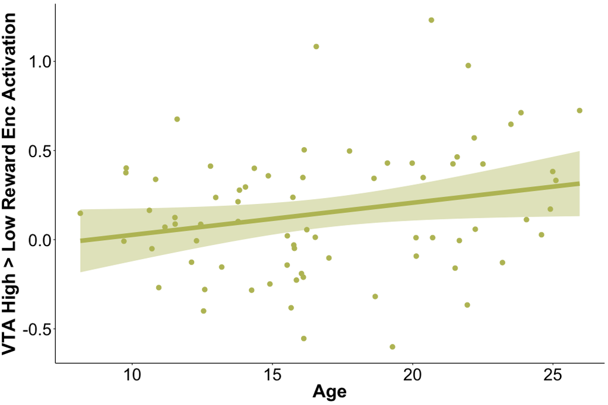

```r
ggplot(anthippRSAdatawbehavfullruns, aes(y = VTA, x = ExactAge.x)) +
  geom_point(size = 3,color = VTA) +
  geom_smooth(method = lm, size = 3, color = VTA, fill = VTA) +
  xlab("Age") + # x axis label
  ylab("VTA High > Low Reward Enc Activation") + # y axis label
  # xlim(0, 0.08) +
  rsa_theme
```

```r
#ggsave('figures/AntHipp_ERS_VTA.png', width = 12, height = 8)
```